# VC data, first sim results

Arnie Seong

04 March 2026

# testing the VC waters

- $Z$ dimension $R$ = 20, results only depend on first 5 $Z$ variables,
- $X$ dimension $p$ = 3,

Just to see if we can adequately capture the data generating functions, tested with $n = 10k$, noise variance $\sigma^2_\epsilon = 0$

## vanilla model

Just proceeding as usual without explicitly modeling the VC structure:

- 2 hidden layers, 8 and 16 units;
- $\tau_0$ agnostic for all.

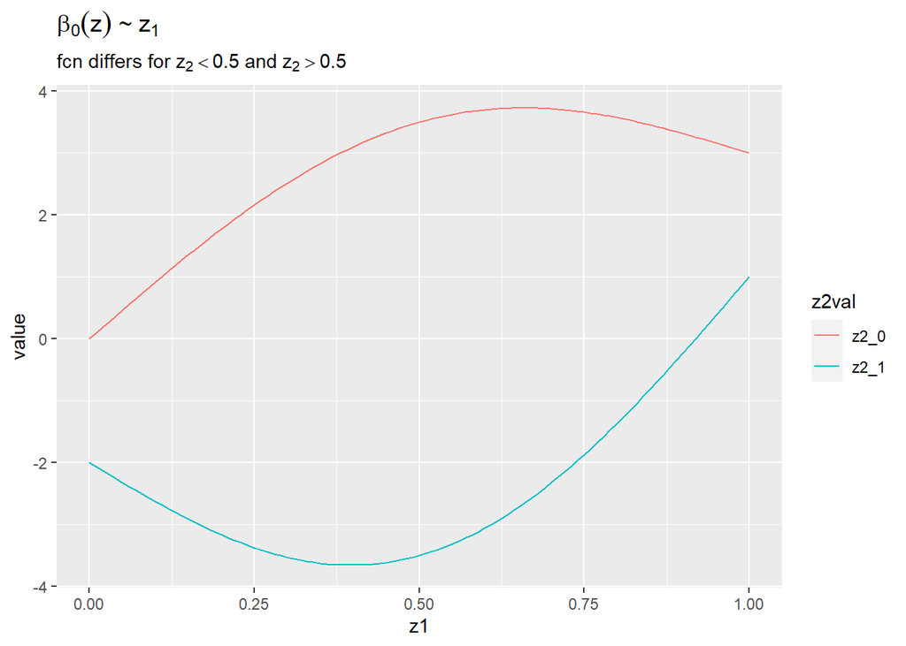

```r
load(resfile_vanilla[1])
nn_mod <- torch_load(modfile_vanilla[1])
plot_b0_true()
```

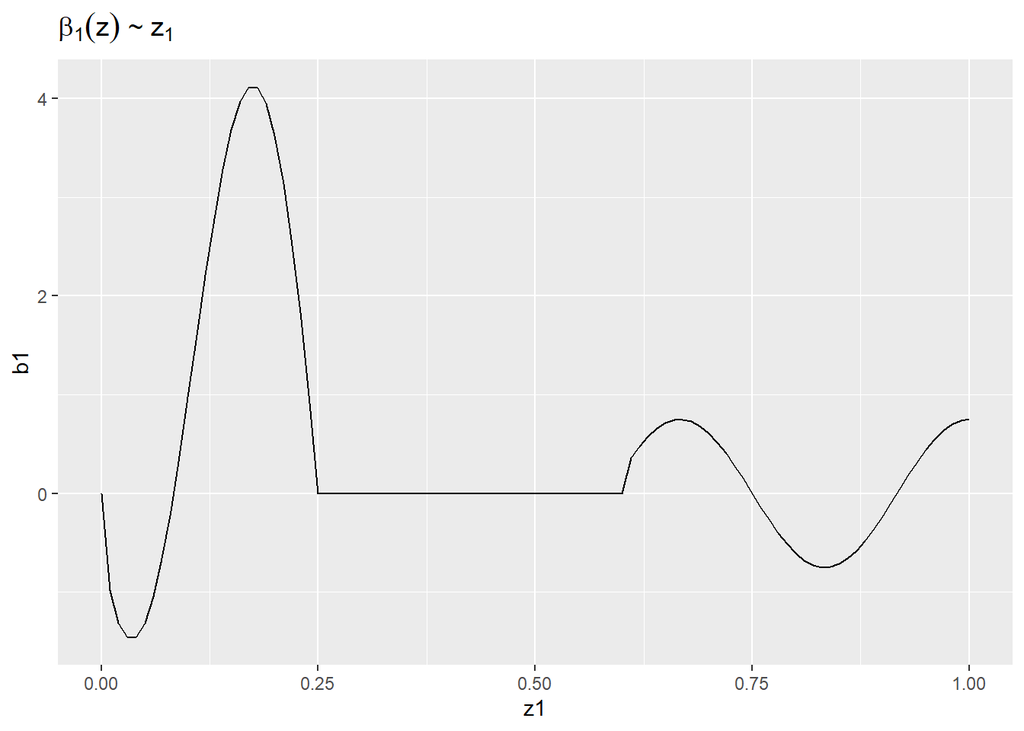

```r
plot_b1_true()
```

```r
sim_res$sim_params$p_0
```

```
## [1] 11.5
```

```r
dim_vec <- c(
  sim_res$sim_params$d_0,
  sim_res$sim_params$d_1,
  sim_res$sim_params$d_2,
  sim_res$sim_params$d_L
)
param_counts_from_dims(dim_vec)
```

```
## layer_1 layer_2 layer_3   TOTAL
##     480     324     102     906
```

```r
varnames <- c(
  paste0("z", 1:sim_res$sim_params$R),
  paste0("x", 1:sim_res$sim_params$p)
)
showvars <- c(
  paste0("z", 1:5),
  paste0("x", 1:sim_res$sim_params$p)
)
true_vec <- varnames %in% showvars
```

### results

#### sim 1

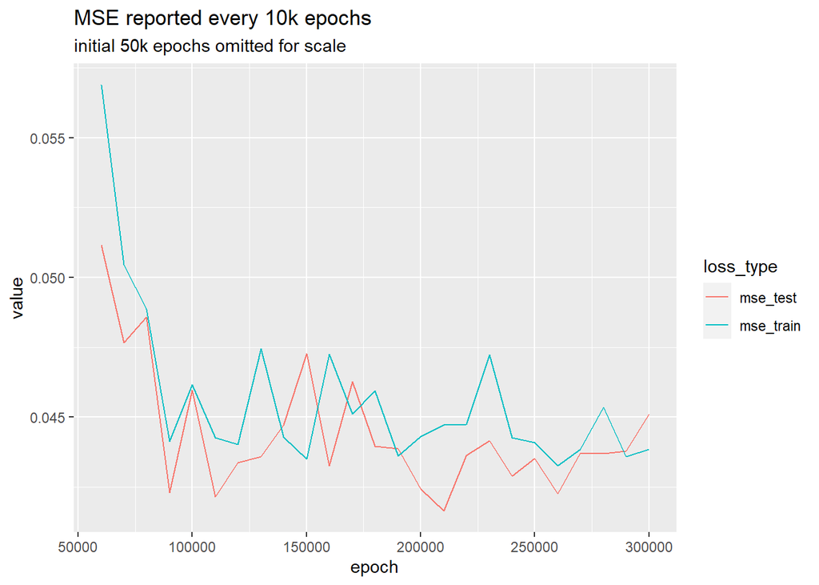

```r
loss_pltfcn(sim_res, burn = 5e4)$mse_plt
```

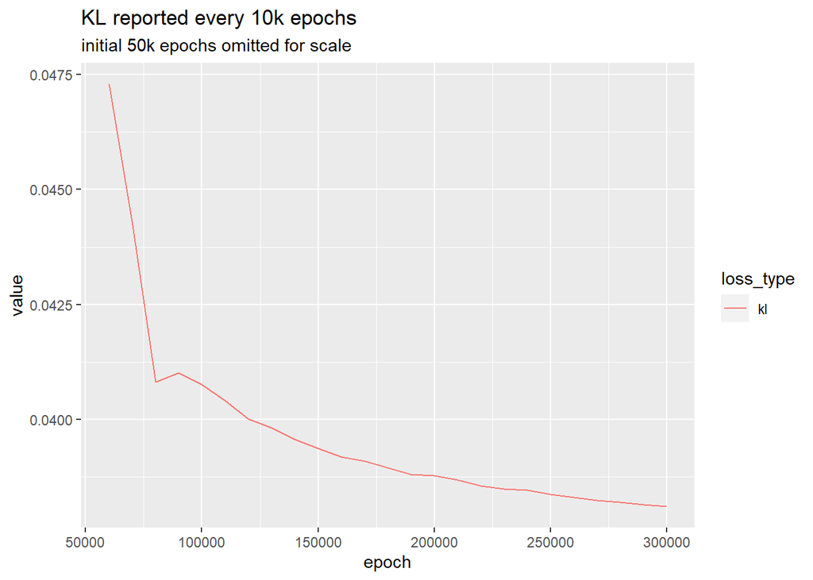

```r
loss_pltfcn(sim_res, burn = 5e4)$kl_plt
```

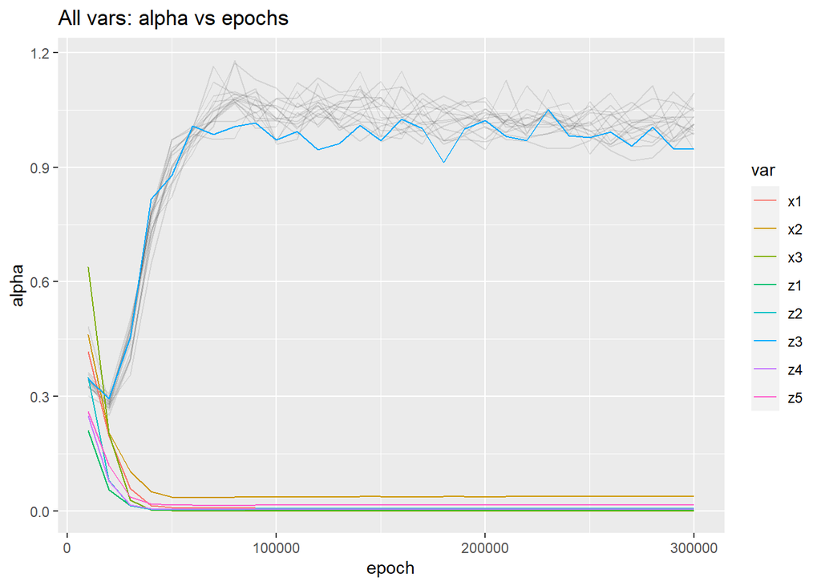

```r
kmat_tc <- sim_res$kappa_tc_mat
kmat_gl <- sim_res$kappa_mat
kmat_lo <- sim_res$kappa_local_mat
kmat_fc <- sim_res$kappa_fc_mat

colnames(sim_res$alpha_mat)  <-
  colnames(kmat_tc) <-
  colnames(kmat_gl) <-
  colnames(kmat_lo) <- varnames

if (!is.null(sim_res$kappa_fc_mat)){
  kmat_fc <- sim_res$kappa_fc_mat
  colnames(kmat_fc) <- varnames
}

varmat_pltfcn(
  sim_res$alpha_mat,
  y_name = "alpha",
  burn = 0,
  show_vars = showvars
)$all_vars_plt
```

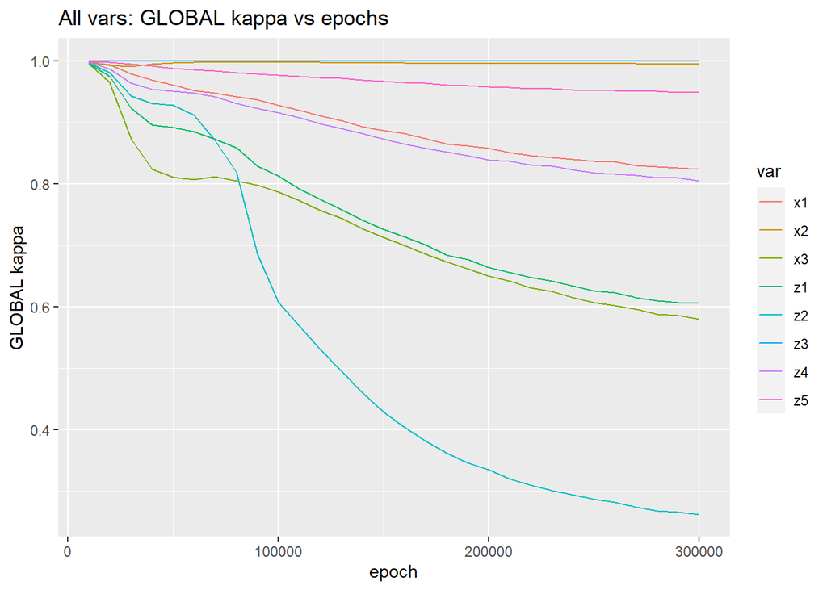

```r
varmat_pltfcn(
  kmat_gl,
  y_name = "GLOBAL kappa",
  burn = 0,
  show_vars = showvars
)$all_vars_plt
```

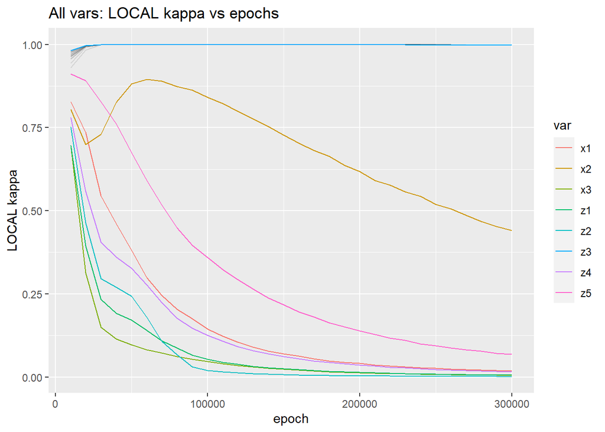

```r
varmat_pltfcn(
  kmat_lo,
  y_name = "LOCAL kappa",
  burn = 0,
  show_vars = showvars
)$all_vars_plt
```

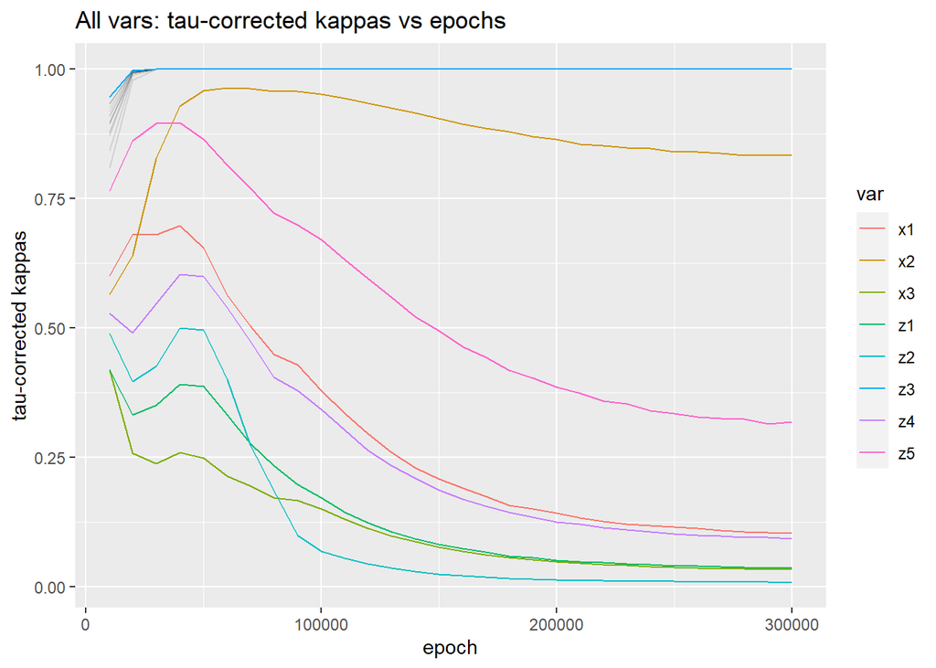

```r
varmat_pltfcn(
  kmat_tc,
  y_name = "tau-corrected kappas",
  burn = 0,
  show_vars = showvars
)$all_vars_plt
```

```r
if (!is.null(sim_res$kappa_fc_mat)){
  varmat_pltfcn(
    kmat_fc,
    y_name = "frob-corrected kappas",
    burn = 0,
    show_vars = showvars
  )$all_vars_plt
}
```

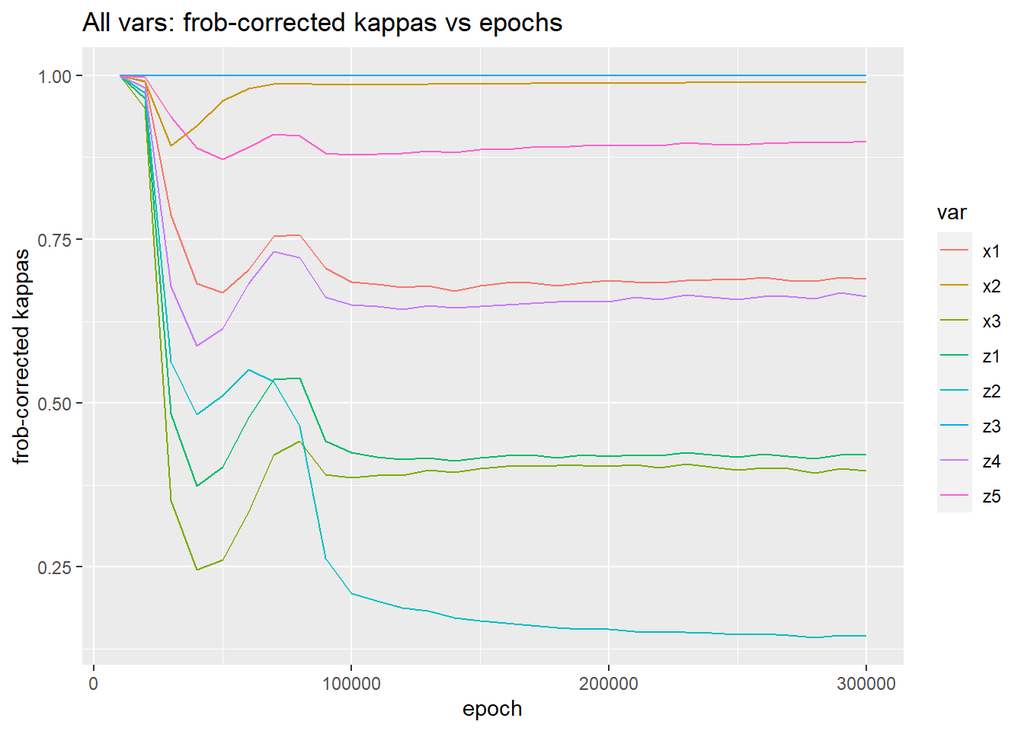

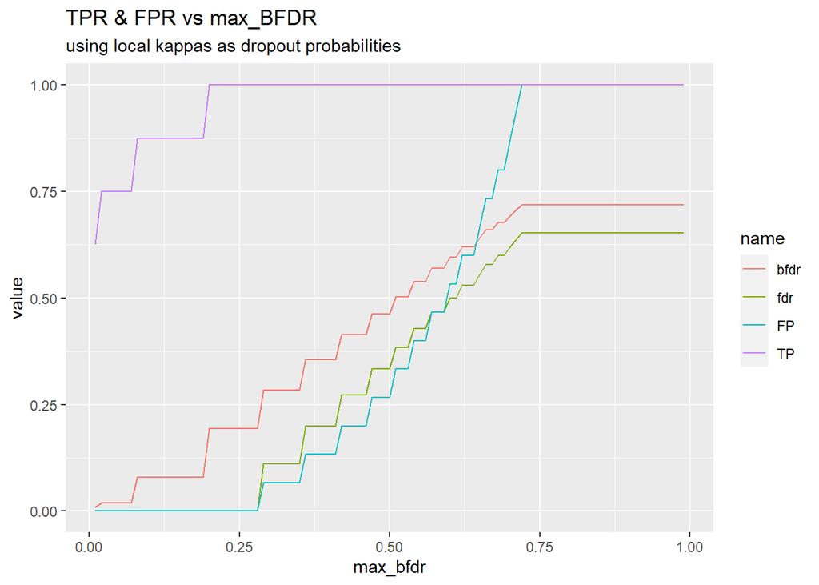

```r
err_by_max_bfdr(
  kmat_lo[nrow(kmat_lo), ],
  true_vec = true_vec
)$plt_fdrs +
  labs(
    subtitle = "using local kappas as dropout probabilities"
  )
```

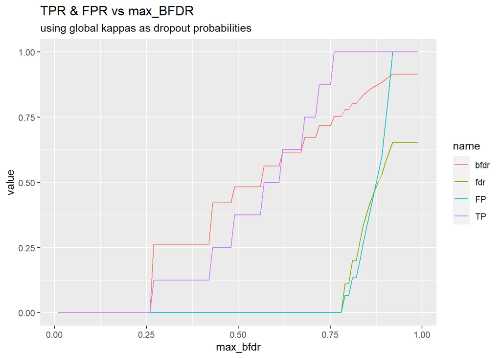

```r
err_by_max_bfdr(
  kmat_gl[nrow(kmat_gl), ],
  true_vec = true_vec
)$plt_fdrs +
  labs(
    subtitle = "using global kappas as dropout probabilities"
  )
```

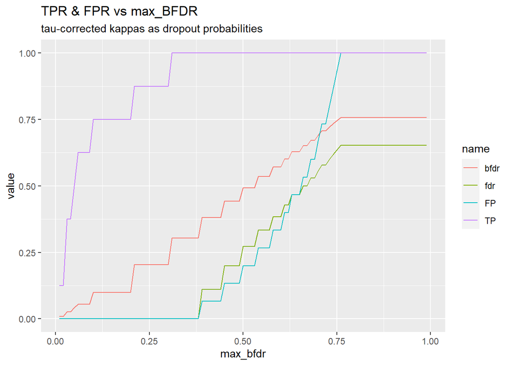

```r
err_by_max_bfdr(
  kmat_tc[nrow(kmat_tc),],
  true_vec = true_vec
)$plt_fdrs +
  labs(
    subtitle = "tau-corrected kappas as dropout probabilities"
  )
```

```r
if (!is.null(sim_res$kappa_fc_mat)){
  err_by_max_bfdr(
    kmat_fc[nrow(kmat_fc),],
    true_vec = true_vec
  )$plt_fdrs +
    labs(
      subtitle = "frob-corrected kappas as dropout probabilities"
    )
}
```

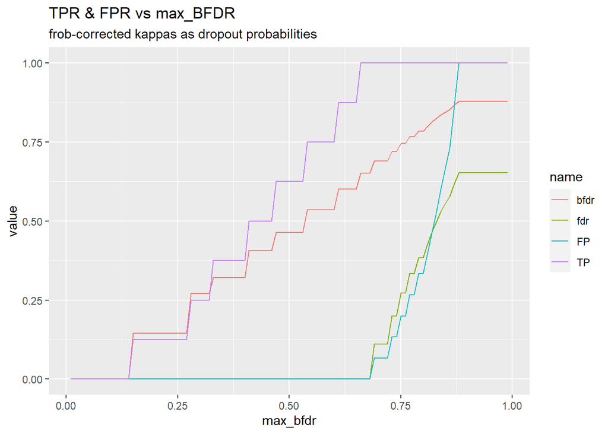

#### sim 2

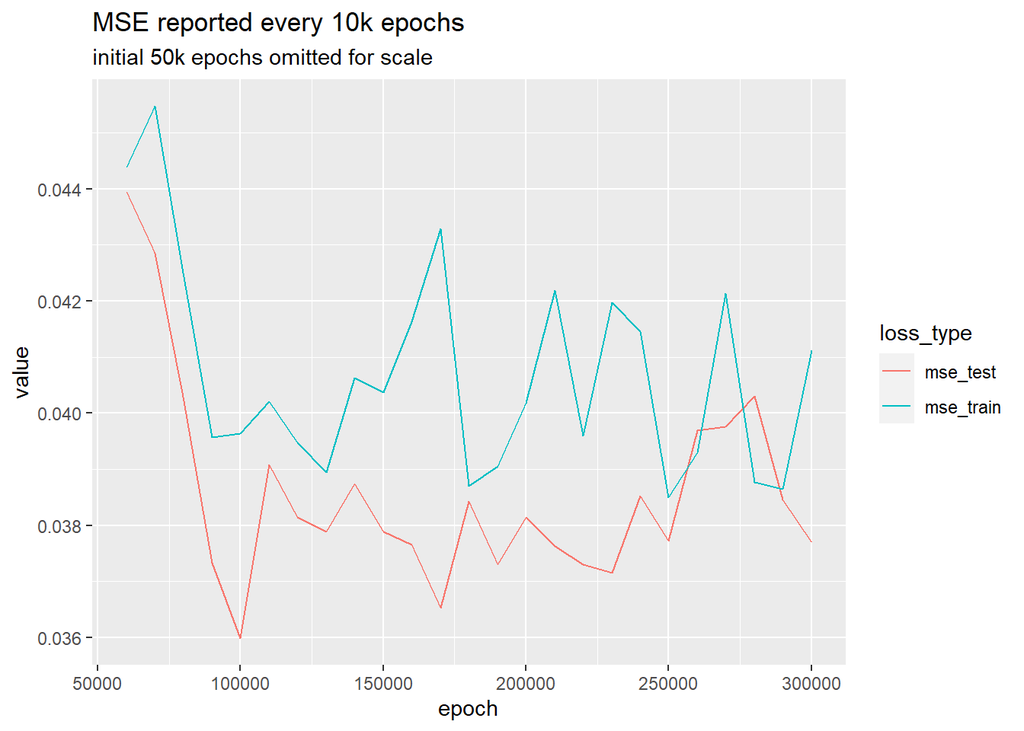

```r
load(resfile_vanilla[2])
nn_mod <- torch_load(modfile_vanilla[2])
loss_pltfcn(sim_res, burn = 5e4)$mse_plt
```

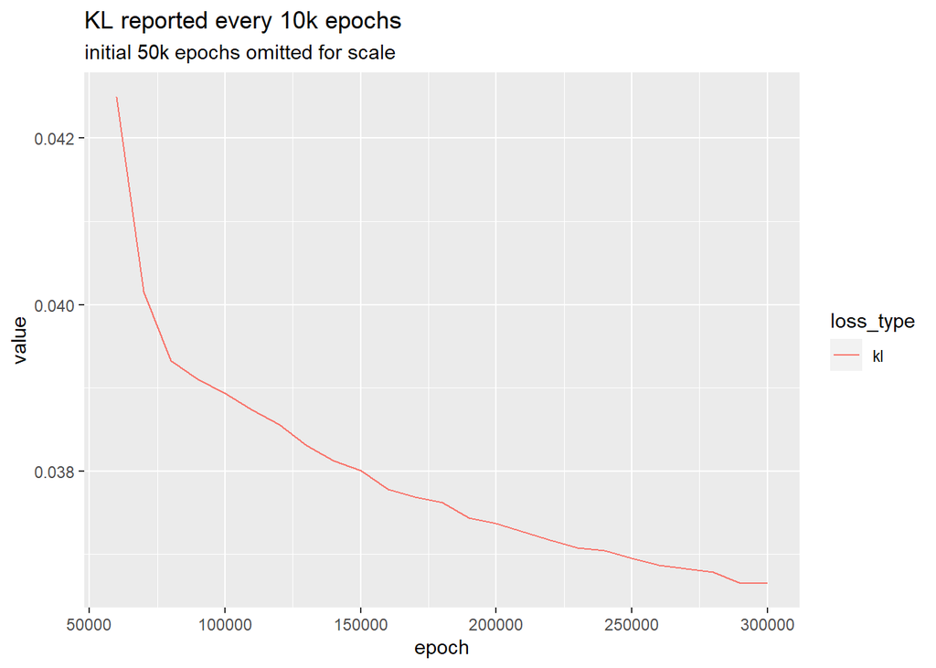

```r
loss_pltfcn(sim_res, burn = 5e4)$kl_plt
```

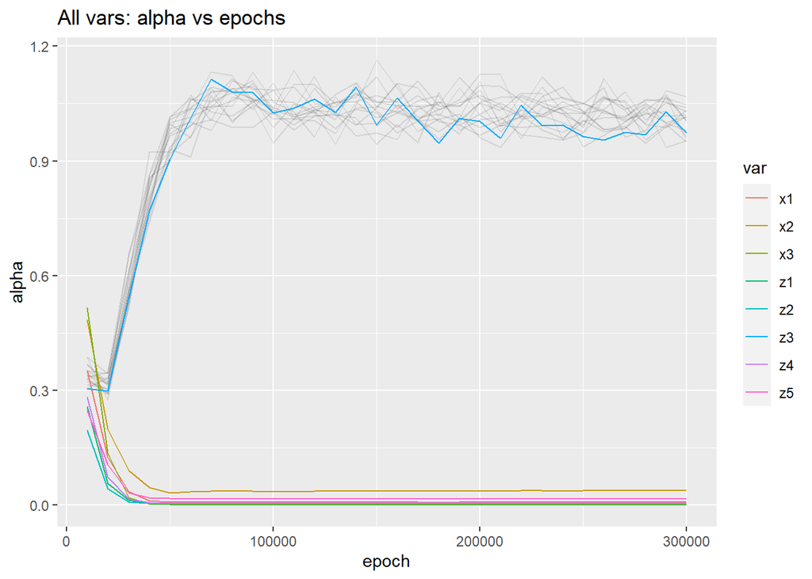

```r
kmat_tc <- sim_res$kappa_tc_mat
kmat_gl <- sim_res$kappa_mat
kmat_lo <- sim_res$kappa_local_mat
kmat_fc <- sim_res$kappa_fc_mat

colnames(sim_res$alpha_mat)  <-
  colnames(kmat_tc) <-
  colnames(kmat_gl) <-
  colnames(kmat_lo) <- varnames

if (!is.null(sim_res$kappa_fc_mat)){
  kmat_fc <- sim_res$kappa_fc_mat
  colnames(kmat_fc) <- varnames
}

varmat_pltfcn(
  sim_res$alpha_mat,
  y_name = "alpha",
  burn = 0,
  show_vars = showvars
)$all_vars_plt
```

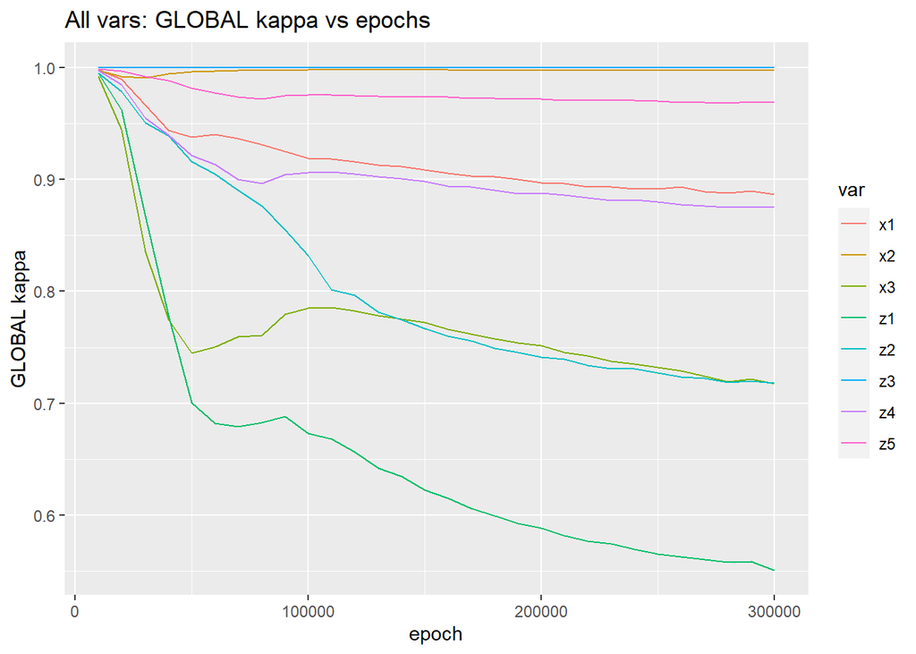

```r
varmat_pltfcn(
  kmat_gl,
  y_name = "GLOBAL kappa",
  burn = 0,
  show_vars = showvars
)$all_vars_plt
```

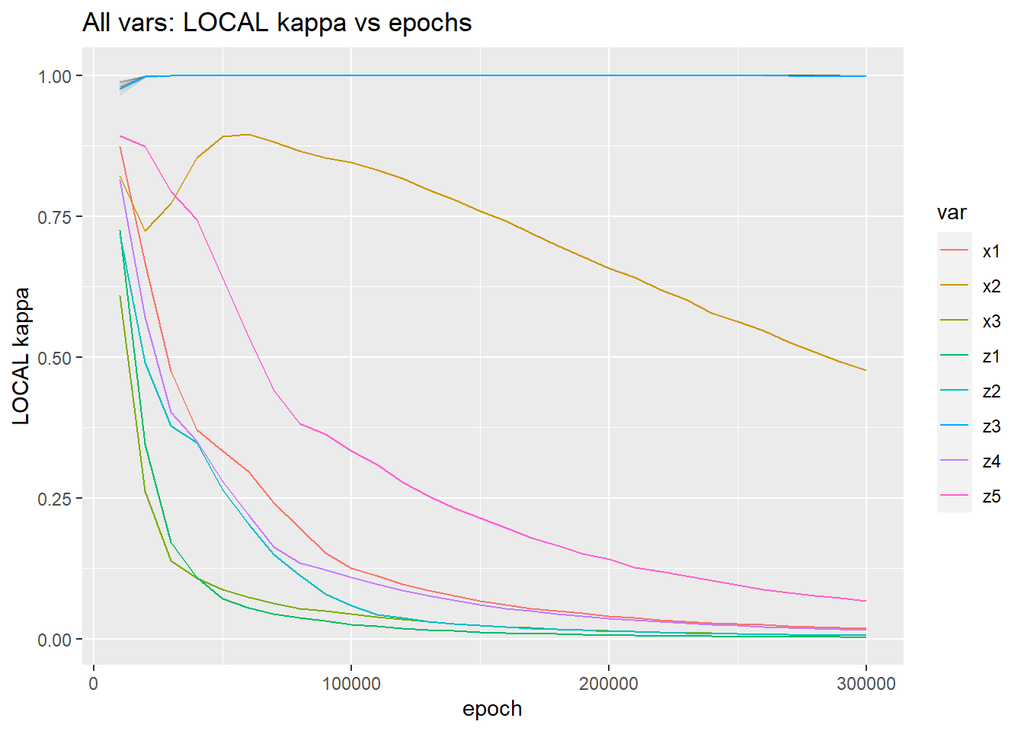

```r
varmat_pltfcn(
  kmat_lo,
  y_name = "LOCAL kappa",
  burn = 0,
  show_vars = showvars
)$all_vars_plt
```

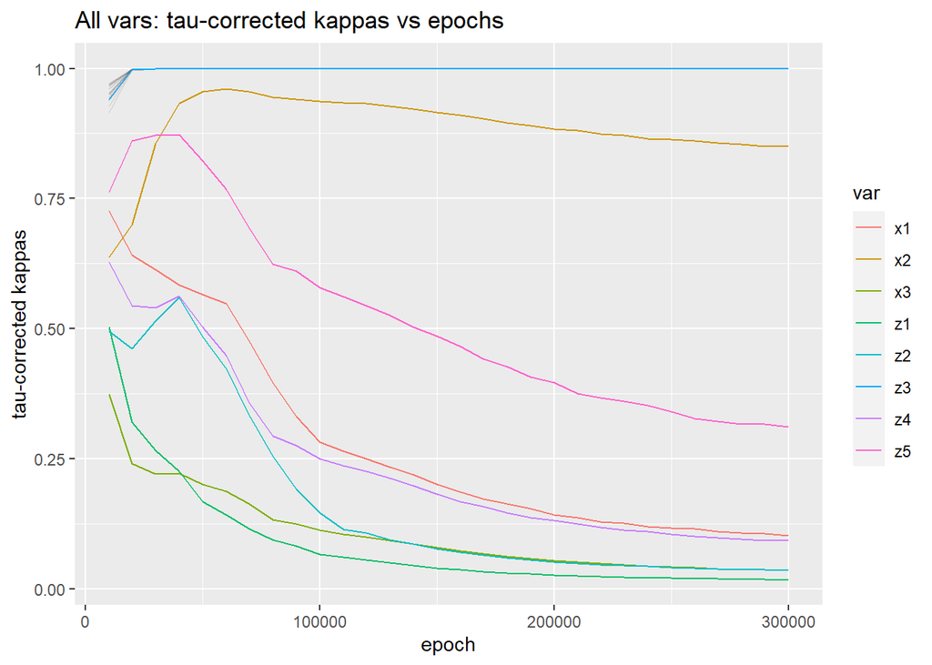

```r
varmat_pltfcn(
  kmat_tc,
  y_name = "tau-corrected kappas",
  burn = 0,
  show_vars = showvars
)$all_vars_plt
```

```r
if (!is.null(sim_res$kappa_fc_mat)){
  varmat_pltfcn(
    kmat_fc,
    y_name = "frob-corrected kappas",
    burn = 0,
    show_vars = showvars
  )$all_vars_plt
}
```

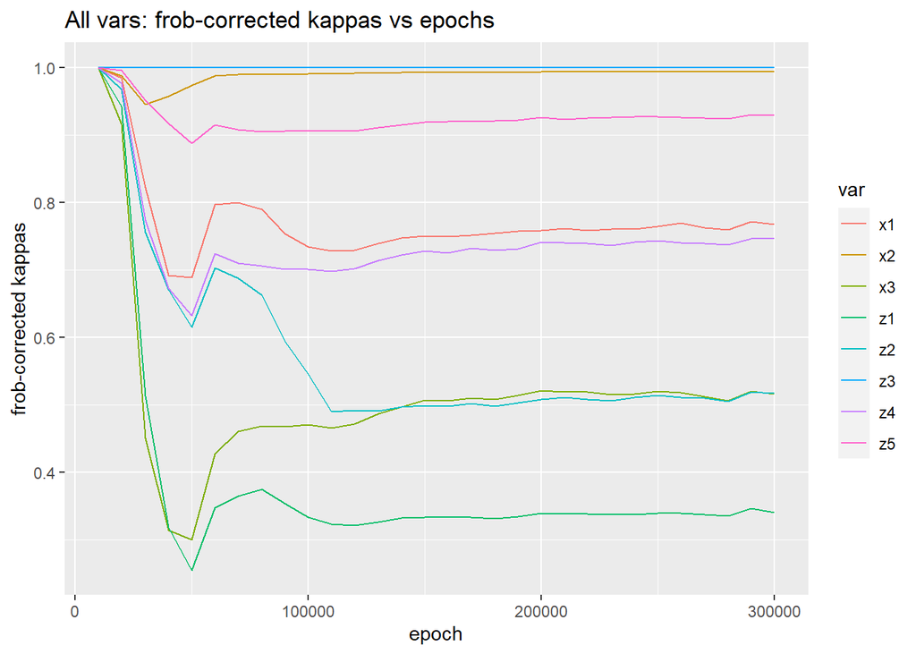

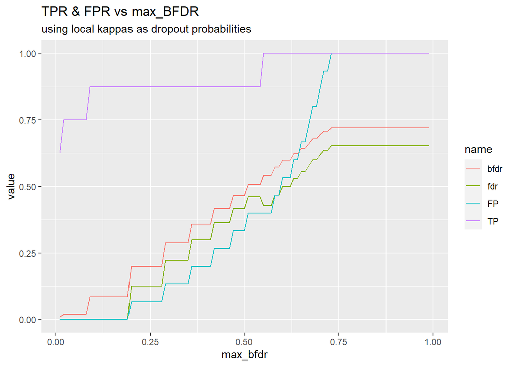

```r
err_by_max_bfdr(
  kmat_lo[nrow(kmat_lo), ],
  true_vec = true_vec
)$plt_fdrs +
  labs(
    subtitle = "using local kappas as dropout probabilities"
  )
```

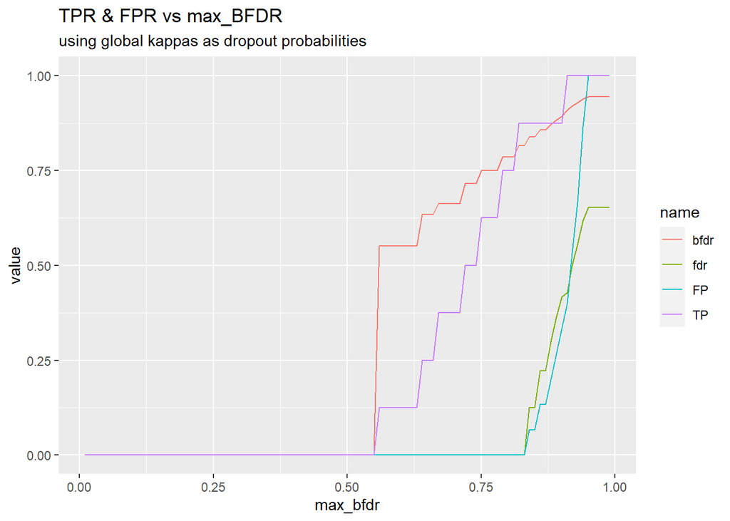

```r
err_by_max_bfdr(
  kmat_gl[nrow(kmat_gl), ],
  true_vec = true_vec
)$plt_fdrs +
  labs(
    subtitle = "using global kappas as dropout probabilities"
  )
```

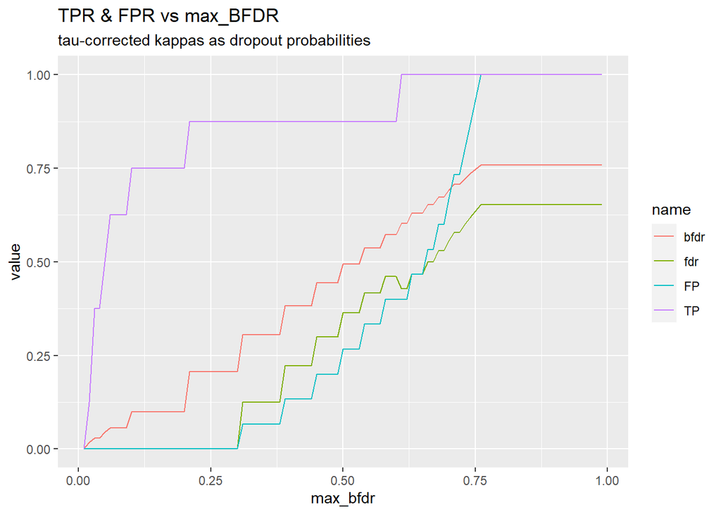

```r
err_by_max_bfdr(
  kmat_tc[nrow(kmat_tc),],
  true_vec = true_vec
)$plt_fdrs +
  labs(
    subtitle = "tau-corrected kappas as dropout probabilities"
  )
```

```r
if (!is.null(sim_res$kappa_fc_mat)){
  err_by_max_bfdr(
    kmat_fc[nrow(kmat_fc),],
    true_vec = true_vec
  )$plt_fdrs +
    labs(
      subtitle = "frob-corrected kappas as dropout probabilities"
    )
}
```

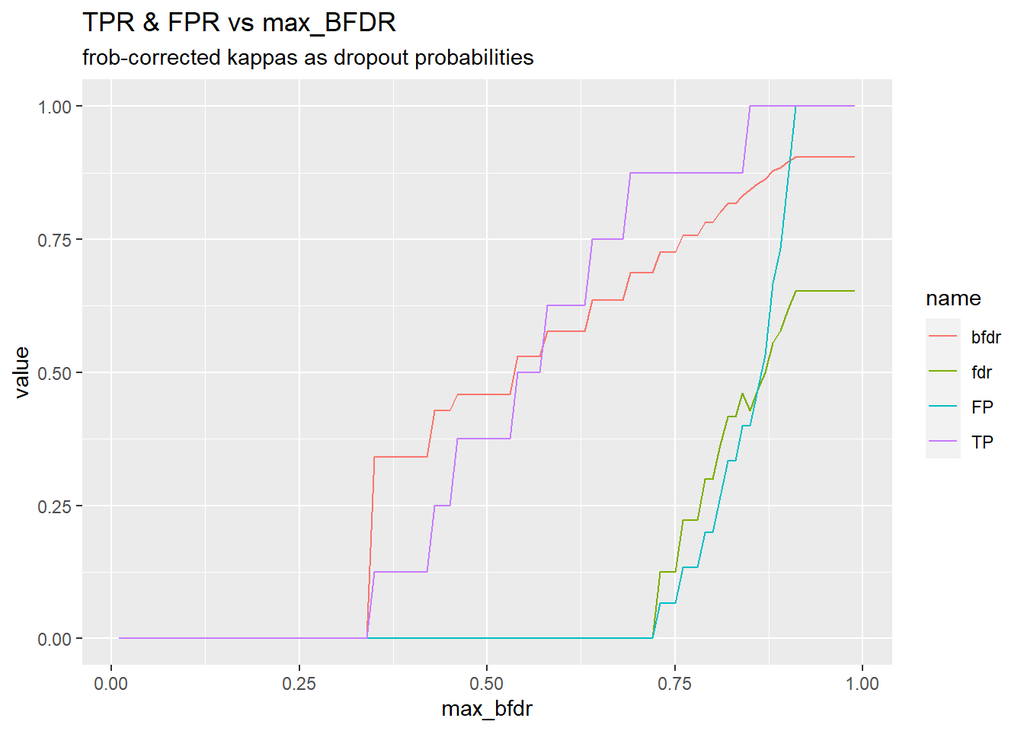

# VC mod testing

Explicitly modeling the VC structure:

- input $X, Z$ vars separately. First $L-1$ layers take only $Z$ variables as input.
- First $L-1$ layers (all but last) used to estimate $\beta_j(Z)$’s and perform variable selection on the $Z$ variables;
- layer $L$ (output layer) does not have a weight matrix; only exists to estimate final scale parameters for the $\beta_j$’s / provide variable selection on the $X$ variables:
  - layer $L$ computes $\hat{y_i} = \beta_0(Z_i) \times \lambda_0 \tau_L + \sum_{j=1}^p \beta_j(Z_i) \times \lambda_j \tau_L \times x_{i,j}$

## first VC sim

```r
sim_res$sim_params
```

```
## $description
## [1] "VCs modeled; agnostic tau_0; sparseVCBART experiment 1 setting"
##
## $seed
## [1] 816
##
## $sim_ID
## [1] "VCmod"
##
## $n_sims
## [1] 2
##
## $train_epochs
## [1] 300000
##
## $report_every
## [1] 10000
##
## $plot_every_x_reports
## [1] 10
##
## $verbose
## [1] TRUE
##
## $want_metric_plts
## [1] TRUE
##
## $want_fcn_plts
## [1] TRUE
##
## $save_metric_plts
## [1] TRUE
##
## $save_fcn_plts
## [1] TRUE
##
## $save_mod
## [1] TRUE
##
## $save_results
```

[output cut: 46 more lines]

```
##
## $sig_eps
## [1] 1
##
## $mu_eps
## [1] 0
##
## $sim_seeds
## [1] 846743 525655
##
## $prior_tau_R
## [1] 0.01
##
## $prior_tau_p
## [1] 0.006
```

```r
dim_list <- sim_res$sim_params[grepl("d_", names(sim_res$sim_params))]
dim_vec <- do.call(c, dim_list)
print(dim_vec)
```

```
##  d_0  d_1  d_2 d_p1  d_L
##   20    8   16    4    1
```

```r
# param_counts_from_dims is slight overcount (written for regular hshoe layers)
# subtract (d_in*d_out + 1)*2 from param counts b/c vc layer has no weights/bias
param_counts_from_dims(dim_vec)
```

```
## layer_1 layer_2 layer_3 layer_4   TOTAL
##     420     324     204      30     978
```

```r
nn_mod$children
```

```
## $fc1
## An `nn_module` containing 420 parameters.
##
## -- Parameters ------------------------------------------------------------------
## * sa_mu: Float [1:1]
## * sa_logvar: Float [1:1]
## * sb_mu: Float [1:1]
## * sb_logvar: Float [1:1]
## * atilde_mu: Float [1:20]
## * atilde_logvar: Float [1:20]
## * btilde_mu: Float [1:20]
## * btilde_logvar: Float [1:20]
## * weight_mu: Float [1:8, 1:20]
## * weight_logvar: Float [1:8, 1:20]
## * bias_mu: Float [1:8]
## * bias_logvar: Float [1:8]
##
## $fc2
## An `nn_module` containing 324 parameters.
##
## -- Parameters ------------------------------------------------------------------
## * sa_mu: Float [1:1]
## * sa_logvar: Float [1:1]
## * sb_mu: Float [1:1]
## * sb_logvar: Float [1:1]
## * atilde_mu: Float [1:8]
## * atilde_logvar: Float [1:8]
## * btilde_mu: Float [1:8]
## * btilde_logvar: Float [1:8]
## * weight_mu: Float [1:16, 1:8]
## * weight_logvar: Float [1:16, 1:8]
## * bias_mu: Float [1:16]
## * bias_logvar: Float [1:16]
##
## $fc3
## An `nn_module` containing 204 parameters.
##
## -- Parameters ------------------------------------------------------------------
## * sa_mu: Float [1:1]
## * sa_logvar: Float [1:1]
```

[output cut: 8 more lines]

```
## * bias_mu: Float [1:4]
## * bias_logvar: Float [1:4]
##
## $vc
## An `nn_module` containing 20 parameters.
##
## -- Parameters ------------------------------------------------------------------
## * sa_mu: Float [1:1]
## * sa_logvar: Float [1:1]
## * sb_mu: Float [1:1]
## * sb_logvar: Float [1:1]
## * atilde_mu: Float [1:4]
## * atilde_logvar: Float [1:4]
## * btilde_mu: Float [1:4]
## * btilde_logvar: Float [1:4]
```

```r
varnames <- c(
  paste0("z", 1:sim_res$sim_params$R),
  "b_int",
  paste0("b", 1:sim_res$sim_params$p)
)
showvars <- c(
  paste0("z", 1:5),
  "b_int",
  paste0("b", 1:sim_res$sim_params$p)
)
true_vec <- varnames %in% showvars
```

### results

```r
load(resfile_vc0[1])
nn_mod <- torch_load(modfile_vc0[1])
```

#### sim 1

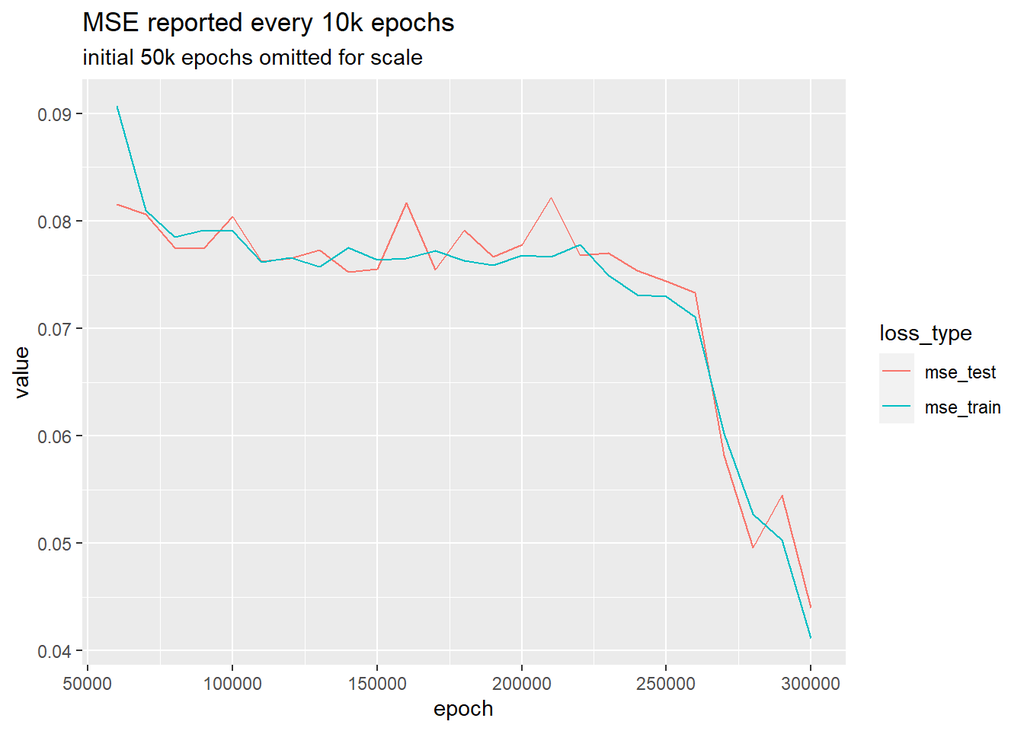

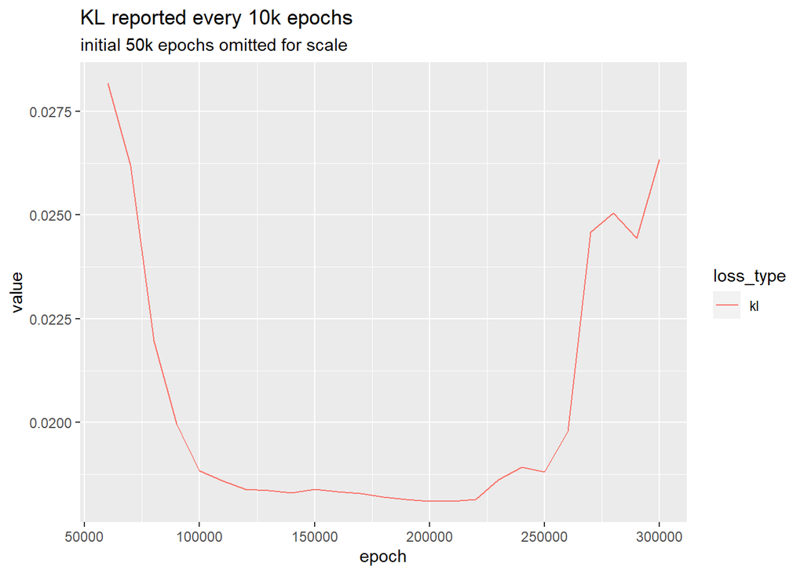

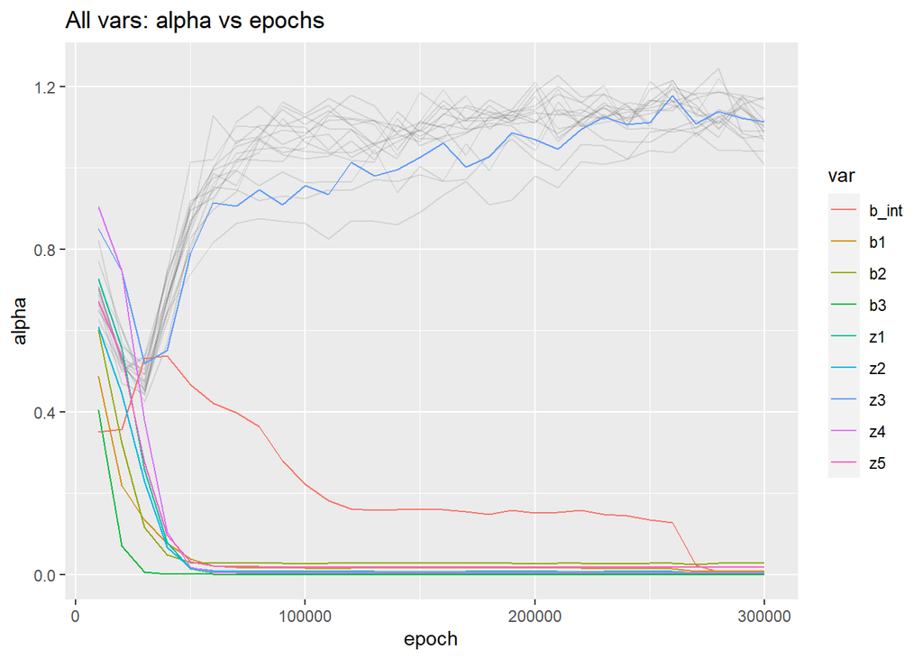

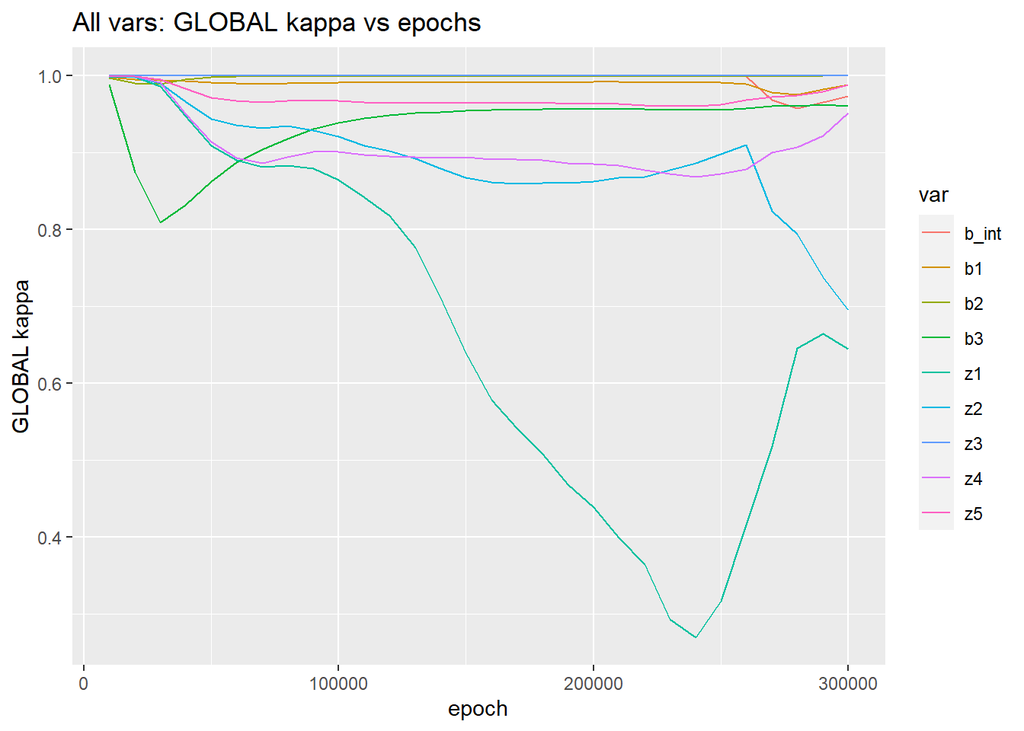